# GEOG-533 Lab 9

Elvis Huang

```r
if(!require("rgdal")){
  install.packages("rgdal")
}
if(!require("tmap")){
  install.packages("tmap")
}
if(!require("UScensus2010")){
  install.packages("UScensus2010")
}
if(!require("UScensus2010county")){
  install.county("osx")
}
if(!require("UScensus2010tract")){
  install.tract("osx")
}
if(!require("psych")){
  install.packages("psych")
}
if(!require("raster")){
  install.packages("raster")
}
if(!require("ncdf4")){
  install.packages("ncdf4")
}
```

## Question 1

Use R package **UScensus2010county** to complete the following tasks: (20 pt.)

### Question 1(a)

Plot a map of New York counties using the **plot** function.

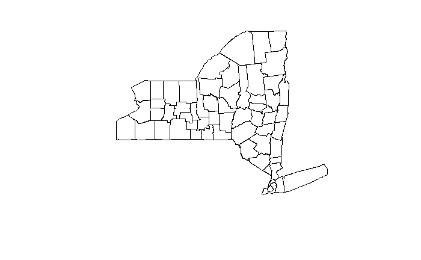

```r
library(UScensus2010county)
data(new_york.county10)
plot(new_york.county10)
```

### Question 1(b)

Plot a map of New York counties using the **qtm** function.

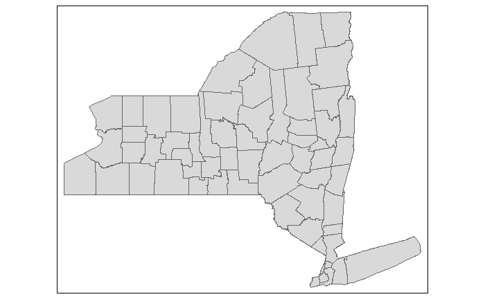

```r
library(UScensus2010county)
library(tmap)
data(new_york.county10)
qtm(new_york.county10)
```

### Question 1(c)

How many counties in New York State?

```r
library(UScensus2010county)
data(new_york.county10)
new_york_df <- new_york.county10@data
nrow(new_york_df)
```

```
[1] 62
```

### Question 1(d)

Whatâs the 3-digit **fips** code of Broome County?

```r
new_york_df[new_york_df$NAME10 == "Broome",]$fips
```

```
[1] "36007"
```

### Question 1(e)

Compute descriptive statistics of the population column (**P0010001**), including total, minimum, maximum, mean, median, and skewness.

```r
library(psych)
data.frame(sum(new_york_df$P0010001),describe(new_york_df$P0010001)[c(8,9,3,5,11)])
```

|  | sum.new_york_df.P0010001. | min | max | mean | median | skew |
| --- | --- | --- | --- | --- | --- | --- |
| X1 | 19378102 | 4836 | 2504700 | 312550 | 91301 | 2.517639 |

### Question 1(f)

Create a histogram and a boxplot of the population.

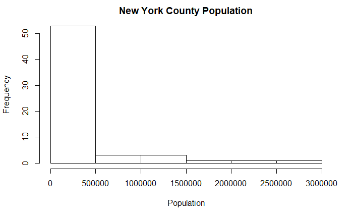

```r
hist(new_york_df$P0010001,main = "New York County Population", xlab = "Population")
```

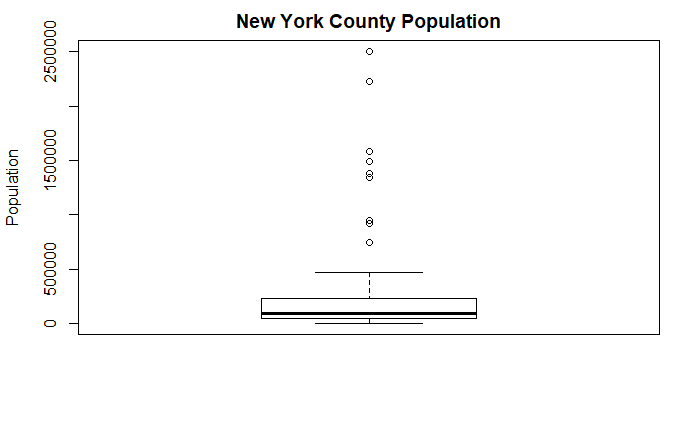

```r
boxplot(new_york_df$P0010001,main = "New York County Population", ylab = "Population")
```

## Question 2

Use R package **UScensus2010tract** to complete the following tasks: (20 pt.)

```r
library(UScensus2010tract)
```

### Question 2(a)

Plot a map of New York census tracts using the **plot** function.

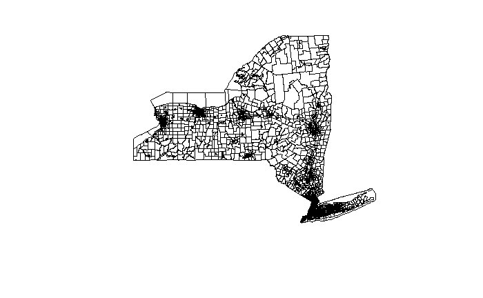

```r
data(new_york.tract10)
plot(new_york.tract10)
```

### Question 2(b)

Compute the total population based on census tracts.

```r
sum(new_york.tract10$P0010001)
```

```
[1] 19378102
```

### Question 2(c)

Select all census tracts in Broome County and plot the map.

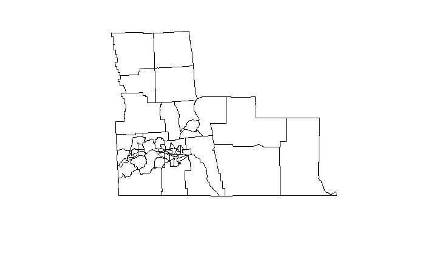

```r
broome <- new_york.tract10[new_york.tract10$county == "007",]
plot(broome)
```

### Question 2(d)

Whatâs the total population of Broome County?

```r
sum(new_york.tract10[new_york.tract10$county == "007",]$P0010001)
```

```
[1] 200600
```

### Question 2(e)

Create a histogram and a boxplot of population based on census tracts of Broome County.

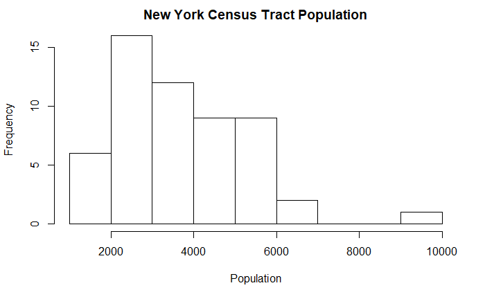

```r
hist((new_york.tract10[new_york.tract10$county == "007",]$P0010001), main = "New York Census Tract Population", xlab = "Population")
```

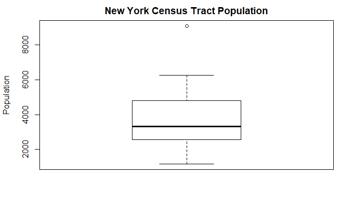

```r
boxplot((new_york.tract10[new_york.tract10$county == "007",]$P0010001), main = "New York Census Tract Population", ylab = "Population")
```

### Question 2(f)

Select the first five columns of the shapefile of Broome County census tract; add a new population ratio column (= census tract population / county population); save the new shapefile to the hard drive.

```r
library(rgdal)
broome5 <- new_york.tract10[new_york.tract10$county == "007",][1:5,]
popratio <- broome5$P0010001/sum(new_york.tract10[new_york.tract10$county == "007",]$P0010001)
broome5$popratio <- popratio
writeOGR(obj = broome5, layer = "broome5", dsn = "Output" , driver = "ESRI Shapefile", overwrite_layer = TRUE)
```

```
NAs introduced by coercion
```